# Modelagem do sequenciamento genético a partir de uma cadeia de Markov

Gustavo Almeida Silva

## Parte 1: Cadeia de Markov, aplicação no sequenciamento genético

A cadeia de Markov é um processo estocástico que busca estimar probabilidades de transição entre estados, e que tem como sua principal propriedade a chamada memória Markoviana. Para calcularmos tais transições temos a chamada matriz de transição de probabilidade, onde essa indica a probabilidade de transição entre cada estado do processo. Essa matriz possui propriedades importantíssima, onde utilizaremos delas nesse estudo * Propriedade da memória Markoviana + Diz respeito à estrutura condicional do processo, dado que estamos em um tempo $T_k$, a probabilidade de transição entre os estados do processo depende apenas do que ocorreu em $T_{k-1}$

- Equação de Chapman-Kolmogorov
  - Com uma matriz de transição, sabemos as probabilidades de transição no tempo $T_k$, porém através da equação de Chapman-Kolmogorov, podemos estimar a matriz de transição em qualquer $T_{k+x}$
- Probabilidade limites
  - Como consequência direta da equação de Chapman-Kolmogorov, se desejamos estimar a matriz em um $\lim_{x \to \infty} T_{k+x}$, estaremos estimando as probabilidades limites da matriz, onde cada coluna possui um valor de convergência igual

As cadeias de Markov possuem um amplo campo de utilização, e nesse estudo buscaremos estimar as probabilidades de transição em uma sequência genética. Para isso, dado uma amostra de DNA, iremos estimar sua matriz de probabilidade e suas probabilidades limites. Como curiosidade, iremos observar qual distribuição cada estado segue, com amostras obtidas através de uma simulação de uma simulação Monte Carlo

## Parte 2: Obtenção dos dados e desenvolvimento das funções

Para a geração dos DNAs, foi utilizado primeiramente o website https://www.bioinformatics.org/sms2/random_dna.html, onde é possível especificar o tamanho amostral desejado. Para o trabalho escolhemos um tamanho genético de 1000 nucleotídeos.

Com as propriedades enunciadas acima, foi possível desenvolver uma função que calcula a matriz de probabilidade de transição e suas probabilidades limites

```r
#Using https://www.bioinformatics.org/sms2/random_dna.html website as DNA generator

DNA=c("ccctatagtctatagcttctcgtctatagttaagattcgtacgcatctggagtgttggcg…")
DNA=strsplit(DNA, split = "")
DNA=DNA[[1]]
```

### Passo 1 - Encontrando os estados

A primeira função a ser definida é a chamada **nucleo_finder**, que irá encontrar os estados do parametro dado, onde esse parametro deve ser um dado categórico

```r
#1
##The factors levels are organize by the alphabetic sequence
nucleo_finder=function(data_dna){
  data_dna=levels(factor(data_dna))
  return(data_dna)
}
```

### Passo 2 - Proporção

A segunda função a ser definida é a chamada **proportion**, que irá calcular a probabilidade de transição de cada nucleotídeo.

```r
#2
proportion=function(data_dna,word1,word2){
  counts=0
  total=0


  for(i in 1:(length(data_dna)-1)){
    if(data_dna[i]==word1)
      {
      total=total+1
    if(data_dna[i+1]==word2)
      counts=counts+1
    }
  }
  return(counts/total)
}
```

### Passo 3 - Matriz de transição

A terceira função a ser definida é a chamada **nucleo_prob_matrix** , que irá utilizar das outras 2 funções definidas(**nucleo_finder**,**proportion**) para calcular a matriz de transição de probabilidades

```r
#3 final
nucleo_prob_matrix=function(data_dna){
  nucleotides=nucleo_finder(data_dna)
  nucleo_matrix=matrix(rep(0,length(nucleotides)**2),byrow = T,nrow=4)

  for(j in 1:length(nucleotides))
    for(i in 1:length(nucleotides)){
      nucleo_matrix[j,i]=proportion(data_dna,nucleotides[j],nucleotides[i])
    }


return(nucleo_matrix)


}
```

### Matriz calculada

Utilizando as funções desenvolvidas para calcular a matriz de transição da sequência genética definida

```r
##Transition probability matrix
nucleo_prob_matrix(DNA)
```

```
##           [,1]      [,2]      [,3]      [,4]
## [1,] 0.2427984 0.1646091 0.2757202 0.3168724
## [2,] 0.2327586 0.2370690 0.2543103 0.2758621
## [3,] 0.2579365 0.2579365 0.2460317 0.2380952
## [4,] 0.2426471 0.2610294 0.2352941 0.2610294
```

```r
#-------Among of functions that returns the stationary distribution  dna´s markov chain (Solving via eigendecomposition)
stationary <- function(transition) {
  stopifnot(is.matrix(transition) &&
        nrow(transition)==ncol(transition) &&
            all(transition>=0 & transition<=1))
  p <- diag(nrow(transition)) - transition
  A <- rbind(t(p),
         rep(1, ncol(transition)))
  b <- c(rep(0, nrow(transition)),
         1)
  res <- qr.solve(A, b)
  names(res) <- paste0("state.", 1:nrow(transition))
  return(res)
}
```

A matriz de DNA apresentou as seguintes probabilidades limites:

```r
##Stationary states
stationary(nucleo_prob_matrix(DNA))
```

```
##   state.1   state.2   state.3   state.4
## 0.2442553 0.2311593 0.2522730 0.2723124
```

Assim, vemos que estamos trabalhando com uma matriz aproximadamente duplamente estocastica, onde a probabilidade limite para cada estado é dado por $1/N\text{, onde N é o número de estados}$

## Geração de sequencias geneticas e a distribuição das probabilidades limites

Apesar o website utilizado para a geração de amostras ser uma ótima ferrmanta uma rápida analise, ela não possui em sua finalidade construir uma grande base de dados. Assim, buscando entender a distribuição das probabilidades limites, foi elaborada uma função iterativa para geração de sequencia geneticas.

Utilizando uma base de 4 amostras geneticas retiradas do site (chamaremos esse conjunto de base primaria), a função constroi uma nova base genetica escolhendo nucleotídeos com probabilidade p estimada da base primaria e aloca essa nova base como uma base primaria. Assim, a cada interação, a base primaria onde a função escolhe aleatoriamente cada nucleotidio aumenta.

```r
#Primary base, selected 4 DNA bases


dna_manipulation=function(DNA){
  DNA=strsplit(DNA, split = "")
  DNA=DNA[[1]]
}

database_dna=
      list('tcaggaattcgcctgccagggtactatgcctccctagaaaatacgagacgttgctaatag…','tcaggaattcgcctgccagggtactatgcctccctagaaaatacgagacgttgctaatag…','cttcactgatactggacggagtatgaaccattttccacgggacagccgcttaataatttg…','atcaatgggtggcggtggcggcaacggttggaccaaaagggtcaggggcgggggcaaatc…')

# dna_simulation=function(database_dna){

    database_dna=lapply(database_dna,dna_manipulation)

    for(k in 1:500){
        teste=vector()
        i=1
        while(length(teste)<=1000){
          if(i>3+k)
                i=1
          random=runif(1,min=1,max=1000)
          teste=c(teste,database_dna[[i]][random])
          i=i+1
        }

      teste=list(teste)
      database_dna=c(database_dna,teste)
    }

# }

database_dna=lapply(database_dna,nucleo_prob_matrix)
database_dna=lapply(database_dna,stationary)

state1=sapply(1:length(database_dna),function(i)database_dna[[i]][1])
state2=sapply(1:length(database_dna),function(i)database_dna[[i]][2])
state3=sapply(1:length(database_dna),function(i)database_dna[[i]][3])
state4=sapply(1:length(database_dna),function(i)database_dna[[i]][4])
```

Com um número grande de amostras de DNAs geradas, foi possível calcular a matriz de transição de cada sequencia genética e assim calcular as probabilidades limites

Construimos um histogramas com essas probabilidades limites estimadas

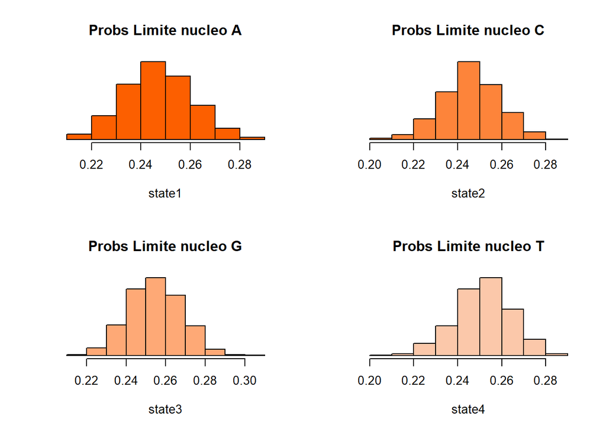

```r
par(mfrow=c(2,2))
hist(state1,freq=F,ylab="",yaxt="n",col='#FC5F00',main='Probs Limite nucleo A')
hist(state2,freq=F,ylab="",yaxt="n",col='#FD843A',main='Probs Limite nucleo C')
hist(state3,freq=F,ylab="",yaxt="n",col='#FEA976',main='Probs Limite nucleo G')
hist(state4,freq=F,ylab="",yaxt="n",col='#FBC8AA',main='Probs Limite nucleo T')
```

Os histogramas sugerem que as probabilidades limites de sequencias genéticas podem ser analisadas por modelos que seguem normalidade. Essa sugestão pode ser utilizada em trabalhos futuros que buscam encontrar irregularidades geneticas